# **Dimensionality reduction techniques**

**Summary of week5 study**

- *In week5, I have studied how to use principle component analysis(**PCA**),correspondence analysis (**CA**) and multiple correspondence analysis (**MCA**) to conduct the dimentionality reduction of multivariate data.*
- *The aim of this kind of analysis is to reduce the complexity of the dataset. The multiple features from the obervations are **linearly combined** as K components. The K components are **uncorrelated** with each other and **ranked** by how much variance of the original data they can explain.*
- *The **biplot** could be used to visulize the observations by **rotated** axis according to the identified components (normally the fisrt two) with **arrows** added to adress the correlation relationships bewteen the features and with the components. CA and MCA are used on **categorical** features for such kind of analysis;*

```r
## Loading packages
library(dplyr)
```

```r
library(tidyr)
library(ggplot2)
library(GGally)
library(corrplot)
library(FactoMineR)
```

## 1. Read the data

In this week, we will use human development indices data for PCA analysis. Original data is from [here](http://hdr.undp.org/en/content/human-development-index-hdi).

```r
data<-"/Users/qingli/Documents/GitHub/IODS-project/Data/Human_data_w5.csv"
human <- read.csv(data,row.names = 1)
dim(human) ## 155 observations with 8 fearures
```

```
## [1] 155   8
```

The dataframe has 155 observation of 8 variables:

- `Life.Exp`: Life expectancy at birth
- `Edu.Exp`: Expected years of schooling
- `GNI`: Gross National Income per capita
- `Mat.Mor`: Maternal mortality ratio
- `Ado.Birth`:Adolescent birth rate
- `Parli.F`: Percetange of female representatives in parliament
- `Edu2.FM`: Edu2.F / Edu2.M
- `Labo.FM`: Labo2.F / Labo2.M

**Note**: “**Edu2.F**” = Proportion of females with at least secondary education; “**Edu2.M**” = Proportion of males with at least secondary education; “**Labo.F**” = Proportion of females in the labour force; “**Labo.M**” " Proportion of males in the labour force;

*The correlation of the 8 features*

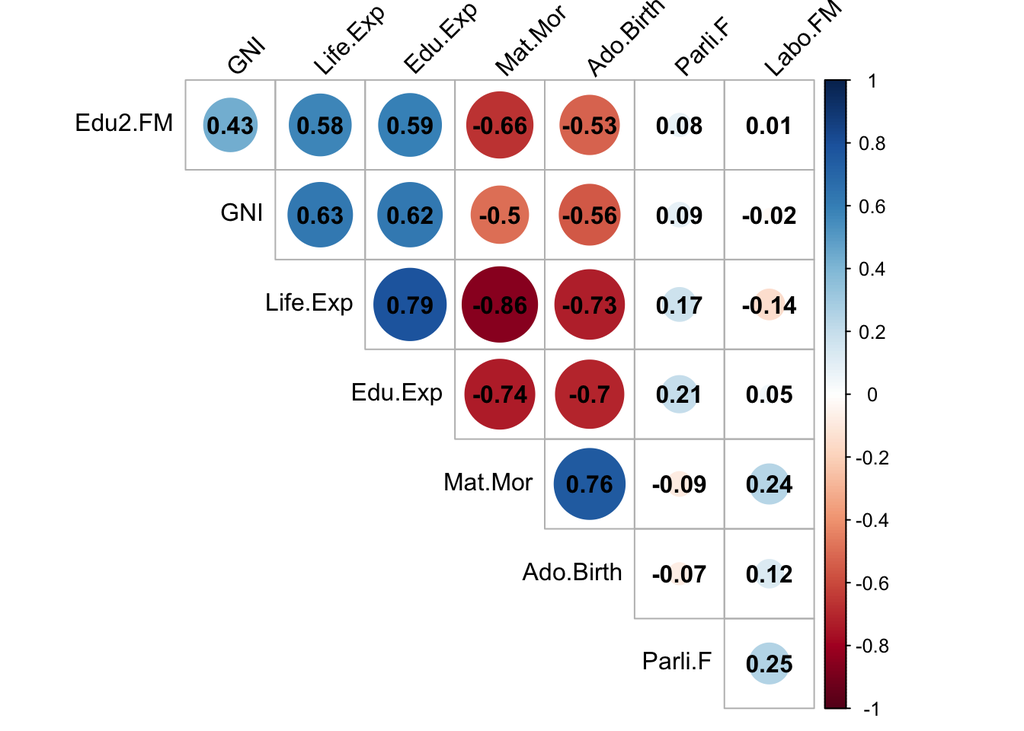

```r
## compute the correlation matrix
cor_matrix <- cor(human)
corrplot(cor_matrix,method="circle",
         type="upper", order="hclust",
         addCoef.col = "black", # Add coefficient of correlation
         tl.col="black", tl.srt=45, #Text label color and rotation
         # Combine with significance
         # hide correlation coefficient on the principal diagonal
         diag=FALSE)
```

From above figure, we see `Life.Exp` vs `Edu.exp` are positively correlated (*r*=0.79) with each other, followed by `Mat.Mor` vs `Ado.Birth` (*r*=0.76) and `GNI` vs `Life_Exp`(*r*=0.63). In contrast, `Life_Exp` is negatively correlated with `Mat_Mor` and `Ado_Birth` with *r*=-0.86 and *r*=-0.73. Also, `Edu.exp` is in the opposite trend of `Mat_Mor` and `Ado_Birth` as `Life_Exp`. It is intresting to know that longer life expectancy implies longer expected education time, and there are lower mortality ratio and adolescent birth rate among those people. Overall, there are 5 variables with the abosolute correlation coefficients over 0.5, which means the uncorrelated components by a PCA analysis will provide us a clear way to understand the data.

*Distribution of the variables*

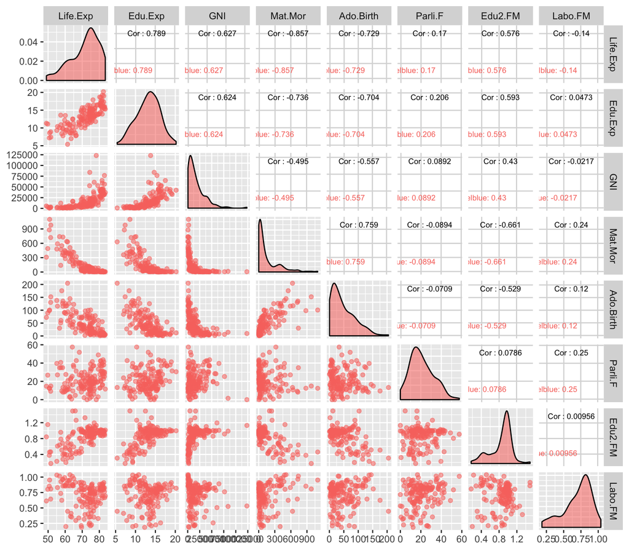

```r
ggpairs(human, mapping = aes(col='steelblue',alpha=0.05),
        lower = list(combo =wrap("facethist", bins = 30)),
        upper = list(continuous = wrap("cor", size = 2.5)))
```

This figure shows the scatter plots of 8 features in `human` with their correlation coefficients in the upper corner, which are carrying the same information with the correlation plot above but in a different graphical perspective. The diagonal of the figure gives the distributions of the variables. Most of them are not normally distributed by eye. It’s worthy to mention that `Edu.Exp` and `Prali.F` are close to be Gaussian distributed.

## 2. PCA on not standardized data

Next, we will apply PCA on unstandardized `human` data.

```r
pca_unscaled_human <- prcomp(human)
summary(pca_unscaled_human)
```

```
## Importance of components:
##                              PC1      PC2   PC3   PC4   PC5   PC6    PC7
## Standard deviation     1.854e+04 185.5219 25.19 11.45 3.766 1.566 0.1912
## Proportion of Variance 9.999e-01   0.0001  0.00  0.00 0.000 0.000 0.0000
## Cumulative Proportion  9.999e-01   1.0000  1.00  1.00 1.000 1.000 1.0000
##                           PC8
## Standard deviation     0.1591
## Proportion of Variance 0.0000
## Cumulative Proportion  1.0000
```

For the unscaled `human` data, the first component is almost could explain all the variance of our data.

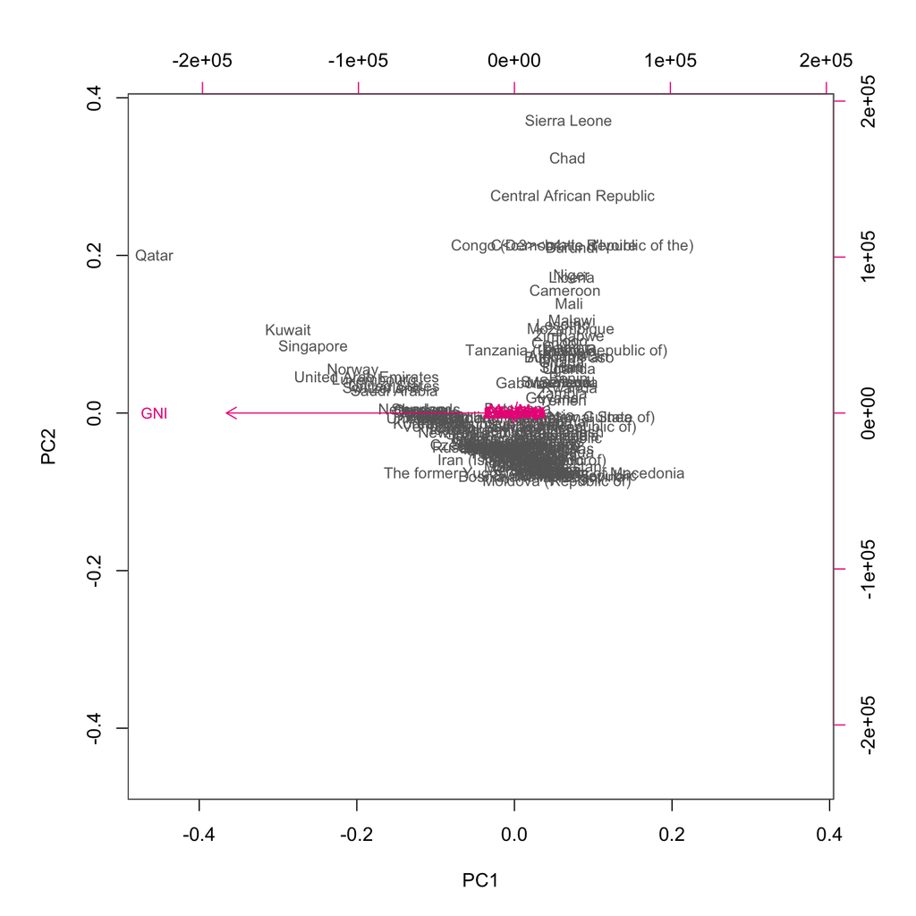

```r
biplot(pca_unscaled_human, choices = 1:2,cex = c(0.8, 0.8),col = c("grey40", "deeppink2"))
```

The biplot tells us `GNI` itself is enough to explain all the variance of the data. Because our data is unscaled, so we will have a look of the summary and the covariance matrix of the data.

```r
summary(human)
```

```
##     Life.Exp        Edu.Exp           GNI            Mat.Mor
##  Min.   :49.00   Min.   : 5.40   Min.   :   581   Min.   :   1.0
##  1st Qu.:66.30   1st Qu.:11.25   1st Qu.:  4198   1st Qu.:  11.5
##  Median :74.20   Median :13.50   Median : 12040   Median :  49.0
##  Mean   :71.65   Mean   :13.18   Mean   : 17628   Mean   : 149.1
##  3rd Qu.:77.25   3rd Qu.:15.20   3rd Qu.: 24512   3rd Qu.: 190.0
##  Max.   :83.50   Max.   :20.20   Max.   :123124   Max.   :1100.0
##    Ado.Birth         Parli.F         Edu2.FM          Labo.FM
##  Min.   :  0.60   Min.   : 0.00   Min.   :0.1717   Min.   :0.1857
##  1st Qu.: 12.65   1st Qu.:12.40   1st Qu.:0.7264   1st Qu.:0.5984
##  Median : 33.60   Median :19.30   Median :0.9375   Median :0.7535
##  Mean   : 47.16   Mean   :20.91   Mean   :0.8529   Mean   :0.7074
##  3rd Qu.: 71.95   3rd Qu.:27.95   3rd Qu.:0.9968   3rd Qu.:0.8535
##  Max.   :204.80   Max.   :57.50   Max.   :1.4967   Max.   :1.0380
```

```r
var(human)
```

```
##                Life.Exp       Edu.Exp           GNI       Mat.Mor
## Life.Exp     69.4232828  1.868220e+01  9.682497e+04 -1.512597e+03
## Edu.Exp      18.6821956  8.067024e+00  3.288345e+04 -4.425512e+02
## GNI       96824.9662547  3.288345e+04  3.438745e+08 -1.944698e+06
## Mat.Mor   -1512.5973775 -4.425512e+02 -1.944698e+06  4.485483e+04
## Ado.Birth  -249.7784240 -8.215424e+01 -4.243095e+05  6.605745e+03
## Parli.F      16.2800884  6.724045e+00  1.900376e+04 -2.176062e+02
## Edu2.FM       1.1597535  4.071587e-01  1.928166e+03 -3.382434e+01
## Labo.FM      -0.2318937  2.671701e-02 -8.013518e+01  1.012323e+01
##               Ado.Birth       Parli.F       Edu2.FM       Labo.FM
## Life.Exp  -2.497784e+02    16.2800884  1.159753e+00 -2.318937e-01
## Edu.Exp   -8.215424e+01     6.7240452  4.071587e-01  2.671701e-02
## GNI       -4.243095e+05 19003.7563259  1.928166e+03 -8.013518e+01
## Mat.Mor    6.605745e+03  -217.6061751 -3.382434e+01  1.012323e+01
## Ado.Birth  1.690201e+03   -33.4746473 -5.259401e+00  9.819617e-01
## Parli.F   -3.347465e+01   131.9683058  2.182832e-01  5.714106e-01
## Edu2.FM   -5.259401e+00     0.2182832  5.838970e-02  4.593874e-04
## Labo.FM    9.819617e-01     0.5714106  4.593874e-04  3.951293e-02
```

## 3. PCA on standardized data

Instead of using covariance matrix (PCA on original data), we will use the correlation matrix for the PCA.

```r
scaled_human <- scale(human)
pca_scaled_human <- prcomp(scaled_human)
summary(pca_scaled_human)
```

```
## Importance of components:
##                           PC1    PC2     PC3     PC4     PC5     PC6
## Standard deviation     2.0708 1.1397 0.87505 0.77886 0.66196 0.53631
## Proportion of Variance 0.5361 0.1624 0.09571 0.07583 0.05477 0.03595
## Cumulative Proportion  0.5361 0.6984 0.79413 0.86996 0.92473 0.96069
##                            PC7     PC8
## Standard deviation     0.45900 0.32224
## Proportion of Variance 0.02634 0.01298
## Cumulative Proportion  0.98702 1.00000
```

The new PCA results show that the top 3 principle components could explain 53.61%, 16.24% and 9.57% of the toal variance, respectively. Taken together, these three could cover 79.41% variance of the original dataset.

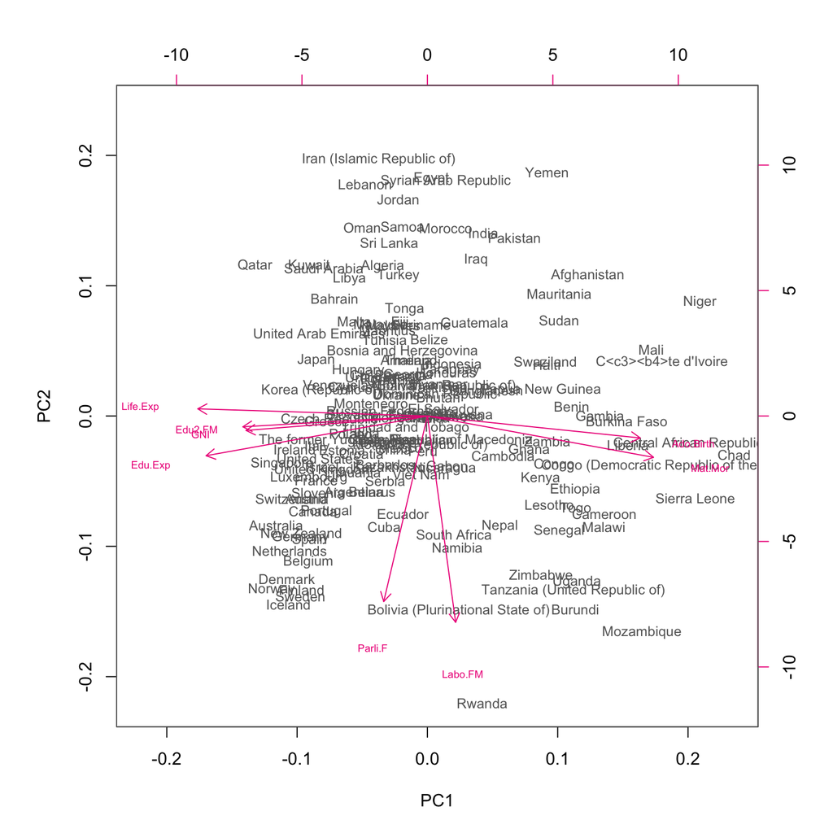

```r
biplot(pca_scaled_human, choices = 1:2,cex = c(0.8, 0.6),col = c("grey40", "deeppink2"))
```

- After scaled the data, we could see more information from the above biplot. From my own perspective, the first component could be explained by the economy development levels of those countries. The countries on the left of the figure (*e.g.* Qatar, United Arab Emirates, Australia *etc.*) have higher income per citizen. The ones in the middle, like South Africa, Nepal and Sudan, are the less developed compared to them. However, the countries on the right part of the figure are still under developing. Among the eight variables, `Life_Exp`, `Edu2.FM`, `GNI` and `Edu.Exp` have very small angles with each other and displied in the same direction of PC1, which implies that better economy development will lead to higher life expentancy, longer education time, higher female education rate. In addition, `Ado.Brith` and `Mat.Mor` are in the opposite direction with those four variables, but still are highly correlated with the gross income of individuals.
- The PC2 of the biplot seems more related to gender gap probabaly caused by culture difference. In Rwanda, Bolivia, Mozambique and some Nordic countries ( e.g. Iceland, Sweden and Norway, Denmark), it is reported that the percentage of females in the goverment position and the the general labor market is quite high worldwidely. But the situation in Iran, Yemen, Jordan and Syrian for example is opposite probably due to the constraint to be and to hire female employees by their culture.

## 4. MCA on tea dataset

In the last part, we will use tea data to explore MCA, which is to reduce dimension of categorical variables.

```r
## load the data
data(tea)
## check the colnames of tea
colnames(tea)
```

```
##  [1] "breakfast"        "tea.time"         "evening"
##  [4] "lunch"            "dinner"           "always"
##  [7] "home"             "work"             "tearoom"
## [10] "friends"          "resto"            "pub"
## [13] "Tea"              "How"              "sugar"
## [16] "how"              "where"            "price"
## [19] "age"              "sex"              "SPC"
## [22] "Sport"            "age_Q"            "frequency"
## [25] "escape.exoticism" "spirituality"     "healthy"
## [28] "diuretic"         "friendliness"     "iron.absorption"
## [31] "feminine"         "sophisticated"    "slimming"
## [34] "exciting"         "relaxing"         "effect.on.health"
```

```r
dim(tea)
```

```
## [1] 300  36
```

```r
str(tea)
```

```
## 'data.frame':    300 obs. of  36 variables:
##  $ breakfast       : Factor w/ 2 levels "breakfast","Not.breakfast": 1 1 2 2 1 2 1 2 1 1 ...
##  $ tea.time        : Factor w/ 2 levels "Not.tea time",..: 1 1 2 1 1 1 2 2 2 1 ...
##  $ evening         : Factor w/ 2 levels "evening","Not.evening": 2 2 1 2 1 2 2 1 2 1 ...
##  $ lunch           : Factor w/ 2 levels "lunch","Not.lunch": 2 2 2 2 2 2 2 2 2 2 ...
##  $ dinner          : Factor w/ 2 levels "dinner","Not.dinner": 2 2 1 1 2 1 2 2 2 2 ...
##  $ always          : Factor w/ 2 levels "always","Not.always": 2 2 2 2 1 2 2 2 2 2 ...
##  $ home            : Factor w/ 2 levels "home","Not.home": 1 1 1 1 1 1 1 1 1 1 ...
##  $ work            : Factor w/ 2 levels "Not.work","work": 1 1 2 1 1 1 1 1 1 1 ...
##  $ tearoom         : Factor w/ 2 levels "Not.tearoom",..: 1 1 1 1 1 1 1 1 1 2 ...
##  $ friends         : Factor w/ 2 levels "friends","Not.friends": 2 2 1 2 2 2 1 2 2 2 ...
##  $ resto           : Factor w/ 2 levels "Not.resto","resto": 1 1 2 1 1 1 1 1 1 1 ...
##  $ pub             : Factor w/ 2 levels "Not.pub","pub": 1 1 1 1 1 1 1 1 1 1 ...
##  $ Tea             : Factor w/ 3 levels "black","Earl Grey",..: 1 1 2 2 2 2 2 1 2 1 ...
##  $ How             : Factor w/ 4 levels "alone","lemon",..: 1 3 1 1 1 1 1 3 3 1 ...
```

[output cut: 22 more lines]

`tea` dataframe has 300 obs. of 36 variables. Except very few of them, most variables are catergorical with ‘TRUE or FALSE’ anwsers. There is one integer variable showing the obs. ages.

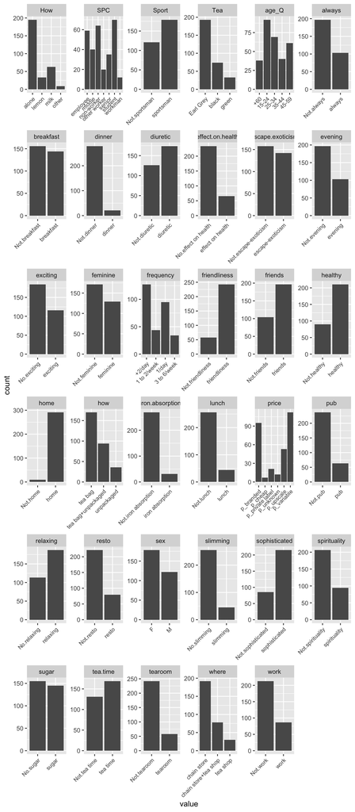

```r
#subset(tea, select = -age ) %>% gather() %>%  dim()

subset(tea, select = -age ) %>% gather() %>% ggplot(aes(value))+geom_bar() + facet_wrap("key", scales = "free") +theme(axis.text.x = element_text(angle = 45, hjust = 1, size = 8))
```